# Análisis descriptivo: tiempo de permanencia en UCI

Sergio A. Barona M.

7/1/2023

# Análisis preliminar

Con el propósito de desarrollar un análisis de supervivencia sobre los pacientes de COVID-19 en Unidades de Cuidados Intesivos (UCI) para Cali, Valle del Cauca, se presenta un análisis descriptivo sobre la variable de interés, a saber, el tiempo de permanencia en UCI. La muestra considerada corresponde a 1.980 pacientes de COVID-19 en UCI durante el período 2020-04-20:2021-11-30. Adicionalmente, se considera el sexo y la edad como covariables de interés. La estructura general de la base de datos se expresa en la **Tabla 1**. Nótese que *Caso* expresa la identificación del individuo según la información del Instituto Nacional de Salud (INS); *Tiempo*, el tiempo de permanencia del paciente en UCI; *Censura*, una variable dicotómica que expresa la censura por derecha[^1] (0 si es un dato censurado, 1 si no lo es); y *Sexo*, una variable dicotómica que expresa el sexo del paciente (0 si es masculino, 1 si es femenino).

Tabla 1: Estructura general de la base de datos sobre el tiempo de permanencia en UCI para Cali, Valle del Cauca. Fuente: INS (2020,2021)

| Caso | Tiempo | Censura | Edad | Sexo |
| --- | --- | --- | --- | --- |
| 187 | 64 | 1 | 74 | 0 |
| 332 | 3 | 1 | 38 | 1 |
| 335 | 3 | 1 | 59 | 0 |
| 374 | 3 | 1 | 29 | 0 |
| 801 | 13 | 1 | 44 | 0 |
| 802 | 36 | 1 | 54 | 0 |
| 806 | 3 | 1 | 26 | 0 |
| 961 | 90 | 1 | 64 | 0 |
| 1080 | 14 | 1 | 57 | 1 |
| 1181 | 87 | 1 | 57 | 0 |
| 1273 | 3 | 1 | 57 | 1 |
| 1275 | 13 | 1 | 55 | 1 |
| 1276 | 3 | 1 | 31 | 1 |
| 1418 | 8 | 1 | 64 | 0 |
| 1423 | 8 | 1 | 44 | 1 |
| 1425 | 3 | 1 | 25 | 1 |
| 1517 | 21 | 1 | 57 | 1 |
| 1693 | 11 | 1 | 68 | 0 |
| 1696 | 3 | 1 | 58 | 1 |
| 1697 | 13 | 1 | 67 | 1 |

Nótese que el tiempo mediano de permanencia en UCI es de 21 días, cuyo rango intercuartílico viene dado por [6, 75]. El tiempo promedio de permanencia en UCI es de 40.61 días. La edad promedio de los pacientes de COVID-19 en UCI es de 61.42 años. Nótese que ~96% de los datos corresponden a datos no-censurados y que, además, el ~64% de los pacientes de COVID-19 en UCI son personas de sexo masculino (véase **Tabla 2**).

Tabla 2: Descripción de la variables y covariables de interés

|  | Tiempo | Edad | Censura | Sexo |
| --- | --- | --- | --- | --- |
|  | Min. : 1.00 | Min. : 1.00 | 0: 73 | 0:1264 |
|  | 1st Qu.: 6.00 | 1st Qu.:52.00 | 1:1907 | 1: 716 |
|  | Median : 21.00 | Median :64.00 | NA | NA |
|  | Mean : 40.61 | Mean :61.42 | NA | NA |
|  | 3rd Qu.: 75.00 | 3rd Qu.:74.00 | NA | NA |
|  | Max. :159.00 | Max. :96.00 | NA | NA |

La **Figura 1** corresponde a la densidad empírica del tiempo de permanencia de pacientes de COVID-19 en UCI. La medida de asimetría (skewness) y la curtosis de la distribución se resumen en la **Tabla 3**. Nótese que la variable de interés no sigue una distribución normal. La distribución muestra una asimetría positiva ($skewness > 0$) de manera tal que el tiempo promedio (40.61) supera el tiempo mediano (21). Y, puesto que $kurtosis \approx 3$, la distribución no muestra colas anchas ni una alta dispersión (i.e. la distribución es mesocúrtica).

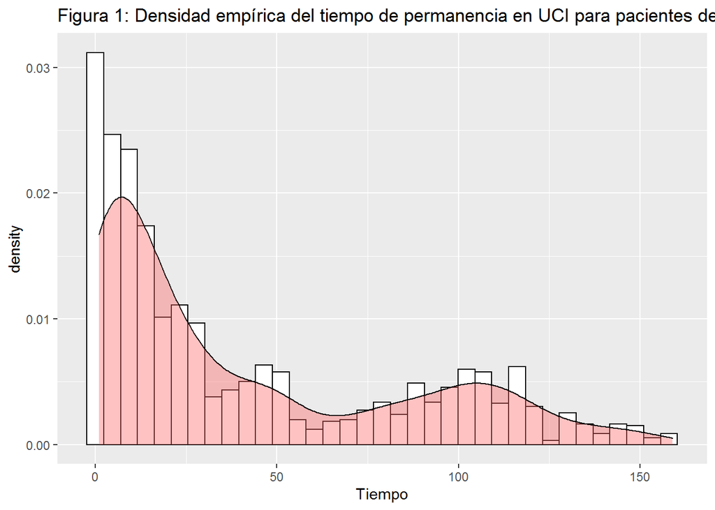

| Skewness | Kurtosis |
| --- | --- |
| 0.9645531 | 2.580534 |

Considérese la **Figura 2** que, en términos generales, presenta una comparación de la medida de asimetría y la curtosis de la distribución anterior con las características de ciertas distribuciones de probabilidad.

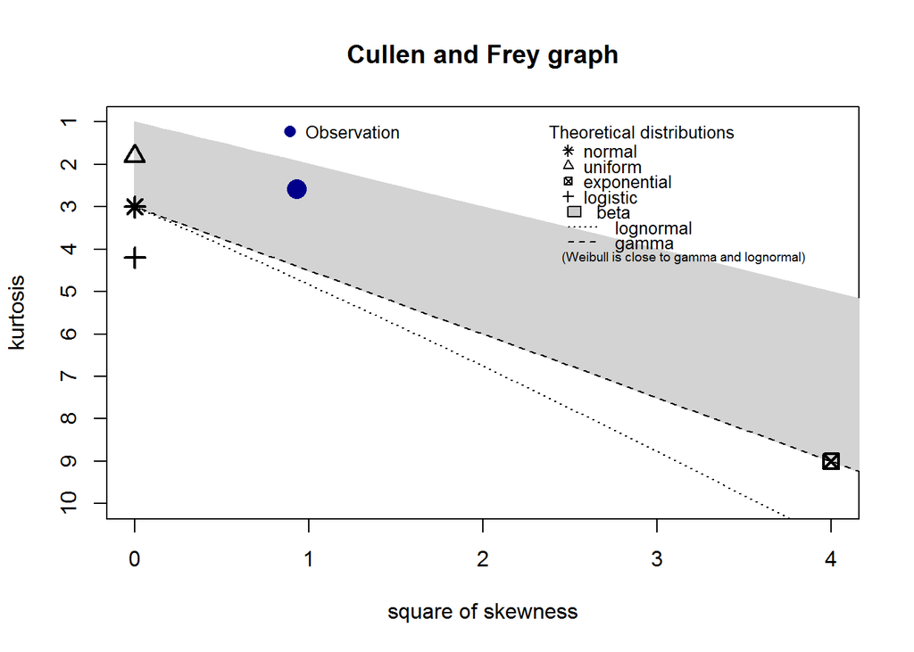

```
## summary statistics
## ------
## min:  1   max:  159
## median:  21
## mean:  40.6101
## estimated sd:  43.00474
## estimated skewness:  0.9652846
## estimated kurtosis:  2.582509
```

# Tratamiento de outliers

Dado el rango intercuartílico (IQR), considérese, por hipótesis, que un valor es atípico si está por fuera del intervalo cuyo límite inferior y superior viene dado, respectivamente, por $Q1 - 1,5*IQR$ y $Q3 + 1,5*IQR$. En general, no se encuentran observaciones atípicas (véase **Tabla 4**).

Tabla 4: Información para la detección de outliers

| Q1 | Q3 | IQR | Lower | Upper |
| --- | --- | --- | --- | --- |
| 6 | 75 | 69 | -97.5 | 178.5 |

[^1]: Existen, por lo menos, tres clases de censura: la censura por derecha es el caso si el tiempo real de supervivencia es igual o superior al observado; la censura por izquierda, si el tiempo real de supervivencia es igual o inferior al tiempo de supervivencia observado; y la censura en intervalo, que combina la censura por derecha y la censura por izquierda, es el caso si el tiempo real de supervivencia se halla contenido en un intervalo conocido (Klein & Moeschberger, 2003). Habida cuenta de la naturaleza del evento de interés, se considera únicamente la censura por derecha y en los siguientes casos: uno, si el paciente permanece en UCI hasta la fecha en que el estudio concluye; y dos, si el paciente muere en UCI en virtud de una causa distinta al COVID-19.